# Course Introduction

Mark Dunning/Mark Fernandes

Last modified: 23 Jul 2018

# Welcome!

[figure not shown]

We’re based at [Cancer Research Uk Cambridge Institute](http://www.cruk.cam.ac.uk/) and [MRC Cancer Unit](https://www.mrc-cu.cam.ac.uk/) on the [Cambridge Biomedical campus](http://cambridge-biomedical.com/) about 2 miles south of here

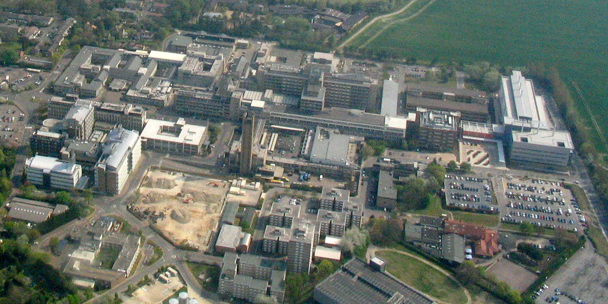

# Who’s who

- [Mark Fernandes (CRUK CI)](http://www.cruk.cam.ac.uk/core-facilities/bioinformatics-core)
- [Shamith Samarajiwa (MRC CU)](http://www.mrc-cu.cam.ac.uk/research/Shamith-Samarajiwa-folder)
- [Dora Bihary (MRC CU)](http://www.mrc-cu.cam.ac.uk/research/Shamith-Samarajiwa-folder)
- [Ashley Sawle (CRUK CI)](http://www.cruk.cam.ac.uk/core-facilities/bioinformatics-core)
- [Alistair Martin (CRUK CI)](http://www.cruk.cam.ac.uk/research-groups/caldas-group)
- [Michael Morgan (CRUK CI)](http://www.cruk.cam.ac.uk/research-groups/caldas-group)
- [Abigail Edwards (CRUK CI)](http://www.cruk.cam.ac.uk/core-facilities/bioinformatics-core)
- [Stephane Ballereau (CRUK CI)](http://www.cruk.cam.ac.uk/core-facilities/bioinformatics-core)

Huge thanks too to Kelly O’Reilly (CRUK) for admin support, and Gabriella, Paul and Cathy for support in Genetics

# Who are you?

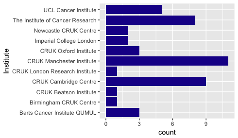

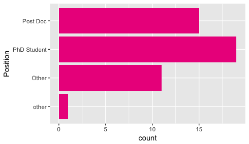

# Admin

- Course runs 09:30 ~ 17:00 each day (Friday is a half-day)
  - Room open from 09:00 each day
- Lunch provided 12:30 - 13:30 each day
  - different room on the same campus, we’ll take you there
- No fixed coffee and tea breaks
  - but you’ll probably have noticed the coffee machine at the back
- Please refrain from using the coffee machine when someone is lecturing
  - you’ll discover why when you use the machine!
- Workshop dinner on Thursday night at Downing College
  - We assume you’re coming unless you’ve told us otherwise
  - Please let us know *a.s.a.p* if you won’t be coming!

# About the Course - “Functional Genomics”

- You will (probably) not come away being an expert
- We cannot teach you everything about NGS data
  - plus, it is a fast-moving field
  - will cover a selection of tools / methods
- However, we hope that you will
  - Understand how your data are processed
  - Be able to explore your data - no programming required
  - Understand the issues and compromises involved in current methods
  - Communicate more effectively with the Bioinformaticians dealing with your data
  - Increase confidence with R and Bioconductor
  - Know where to get help
  - Be able to explore new technologies, methods, tools as they come out
  - Meet your colleagues from other CRUK institutes
  - Have fun!
- All materials will be online after the course
  - tell your colleagues, friends!

# Live note-taking and documentation

- We have an “etherpad” at https://public.etherpad-mozilla.org/p/2018-07-23-functional-genomics
- Use this to ask questions during the talks
- We can post code snippets, links and corrections here too